# modeling

In this portion of the analysis, we will use the LASSO method for regularization of the model. We’ll also try out a decision tree

# load packages and data

```r
library(ggplot2) #for plotting
library(broom) #for cleaning up output from lm()
library(here) #for data loading/saving
library(tidymodels) #for modeling
library(rpart)
library(glmnet)
library(ranger)
library(rpart.plot)  # for visualizing a decision tree
library(vip)         # for variable importance plots
library(gridExtra) # for savings images in grids
#path to data
#note the use of the here() package and not absolute paths
data_location <- here::here("data","processed_data","processeddata.rds")

#load cleaned data.
data <- readRDS(here("data", "processed_data", "mpwrfcombo.rds"))
```

# split data into train and test subsets

```r
# set seed for reproducible analysis (instead of random subset each time)
set.seed(123)
#subset 3/4 of data as training set
data_split <- initial_split(data,
                            prop = 7/10,
                            strata = particles_l) #stratify by MP concentration for balanced outcome

#save sets as data frames
train_data <- training(data_split)
test_data <- testing(data_split)
```

# Cross validation

We want to perform 5-fold CV, 5 times repeated

```r
#create folds (resample object)
set.seed(123)
folds <- vfold_cv(train_data,
                  v = 5,
                  repeats = 5,
                  strata = particles_l) #folds is set up to perform our CV
#linear model set up
lm_mod <- linear_reg() %>%
            set_engine('lm') %>%
            set_mode('regression')

#create recipe for data and fitting and make dummy variables
MP_rec <- recipe(particles_l ~ ., data = train_data) %>% step_dummy(all_nominal())

#workflow set up
MP_wflow <-
  workflow() %>% add_model(lm_mod) %>% add_recipe(MP_rec)

#use workflow to prepare recipe and train model with predictors
MP_fit <-
  MP_wflow %>% fit(data = train_data)

#extract model coefficient
MP_fit %>% extract_fit_parsnip() %>% tidy()
```

```
## # A tibble: 77 × 5
##    term              estimate   std.error statistic    p.value
##    <chr>                <dbl>       <dbl>     <dbl>      <dbl>
##  1 (Intercept)   3280583.     832291.         3.94  0.000544
##  2 lat             31511.       5386.         5.85  0.00000362
##  3 long            51390.      11358.         4.52  0.000118
##  4 year              -29.9       221.        -0.136 0.893
##  5 month            -111.         60.9       -1.82  0.0800
##  6 visual_score       -0.560       2.73      -0.205 0.839
##  7 turbidity.ntu       1.06        5.30       0.200 0.843
##  8 temperature.c     -14.8        13.2       -1.13  0.270
##  9 e.coli.cfu          0.0503      0.0512     0.983 0.335
## 10 quarter           373.        197.         1.90  0.0691
## # … with 67 more rows
```

# Null model performance

```r
#recipe for null model
null_train_rec <- recipe(particles_l ~ 1, data = train_data) #predicts mean of outcome

#null model workflow incorporating null model recipe
null_wflow <- workflow() %>% add_model(lm_mod) %>% add_recipe(null_train_rec)

# I want to check and make sure that the null model worked as it was supposed to, so I want to view the predictions and make sure they are all the mean of the outcome
#get fit for train data using null workflow
nullfittest <- null_wflow %>% fit(data = train_data)
#get predictions based on null model
prediction <- predict(nullfittest, train_data)
test_pred <- predict(nullfittest, test_data)
#the predictions for the train and test data are all the same mean value, so this tells us the null model was set up properly

#Now, we'll use fit_resamples based on the tidymodels tutorial for CV/resampling (https://www.tidymodels.org/start/resampling/)
#fit model with training data
null_fit_train <- fit_resamples(null_wflow, resamples = folds)
```

[output not shown]

[output not shown]

[output not shown]

[output not shown]

[output not shown]

[output not shown]

[output not shown]

[output not shown]

[output not shown]

[output not shown]

[output not shown]

[output not shown]

[output not shown]

[output not shown]

[output not shown]

[output not shown]

[output not shown]

[output not shown]

[output not shown]

[output not shown]

[output not shown]

[output not shown]

[output not shown]

[output not shown]

[output not shown]

```r
#get results
metrics_null_train <- collect_metrics(null_fit_train)
#RMSE for null train fit is 109.4

#repeat for test data
null_test_rec <- recipe(particles_l ~ 1, data = test_data) #predicts mean of outcome
null_test_wflow <- workflow() %>% add_model(lm_mod) %>% add_recipe(null_test_rec) #sets workflow with new test recipe
null_fit_test <- fit_resamples(null_test_wflow, resamples = folds) #performs fit
```

[output not shown]

[output not shown]

[output not shown]

[output not shown]

[output not shown]

[output not shown]

[output not shown]

[output not shown]

[output not shown]

[output not shown]

[output not shown]

[output not shown]

[output not shown]

[output not shown]

[output not shown]

[output not shown]

[output not shown]

[output not shown]

[output not shown]

[output not shown]

[output not shown]

[output not shown]

[output not shown]

[output not shown]

[output not shown]

```r
metrics_null_test <- collect_metrics(null_fit_test) #gets fit metrics
#RMSE for null test fit is 109.4
```

# Model tuning and fitting

Include: 1. Model specification 2. Workflow definition 3. Tuning grid specification 4. Tuning w/ cross-validation + `tune_grid()`

## LASSO model

```r
#based on tidymodels tutorial: case study
#cross validation
set.seed(123)
cell_folds <- vfold_cv(train_data)

#model specification
#lasso <- linear_reg(penalty = tune()) %>% set_engine("glmnet") %>% set_mode("regression")
lasso <- linear_reg() %>%
  set_mode("regression") %>%
  set_engine("glmnet") %>%
  set_args(penalty = tune(), mixture = 1)

#set workflow
lasso_wf <- workflow() %>% add_model(lasso) %>% add_recipe(MP_rec)

#tuning grid specification
lasso_grid <- tibble(penalty = 10^seq(-3, 0, length.out = 30))

#tuning with CV and tune_grid
lasso_res <- lasso_wf %>% tune_grid(resamples = cell_folds,
                                    grid = lasso_grid,
                                    control = control_grid(save_pred = TRUE),
                                    metrics = metric_set(rmse))
```

[output not shown]

[output not shown]

[output not shown]

[output not shown]

[output not shown]

[output not shown]

[output not shown]

[output not shown]

```r
#view model metrics
lasso_res %>% collect_metrics()
```

```
## # A tibble: 30 × 7
##    penalty .metric .estimator  mean     n std_err .config
##      <dbl> <chr>   <chr>      <dbl> <int>   <dbl> <chr>
##  1 0.001   rmse    standard    101.    10    12.7 Preprocessor1_Model01
##  2 0.00127 rmse    standard    101.    10    12.7 Preprocessor1_Model02
##  3 0.00161 rmse    standard    101.    10    12.7 Preprocessor1_Model03
##  4 0.00204 rmse    standard    101.    10    12.7 Preprocessor1_Model04
##  5 0.00259 rmse    standard    101.    10    12.7 Preprocessor1_Model05
##  6 0.00329 rmse    standard    101.    10    12.7 Preprocessor1_Model06
##  7 0.00418 rmse    standard    101.    10    12.7 Preprocessor1_Model07
##  8 0.00530 rmse    standard    101.    10    12.7 Preprocessor1_Model08
##  9 0.00672 rmse    standard    101.    10    12.7 Preprocessor1_Model09
## 10 0.00853 rmse    standard    101.    10    12.7 Preprocessor1_Model10
## # … with 20 more rows
```

```r
#select top models
top_lasso <-
  lasso_res %>% show_best("rmse") %>% arrange(penalty)
top_lasso #view
```

```
## # A tibble: 5 × 7
##   penalty .metric .estimator  mean     n std_err .config
##     <dbl> <chr>   <chr>      <dbl> <int>   <dbl> <chr>
## 1 0.001   rmse    standard    101.    10    12.7 Preprocessor1_Model01
## 2 0.00127 rmse    standard    101.    10    12.7 Preprocessor1_Model02
## 3 0.621   rmse    standard    101.    10    12.6 Preprocessor1_Model28
## 4 0.788   rmse    standard    101.    10    12.6 Preprocessor1_Model29
## 5 1       rmse    standard    101.    10    12.5 Preprocessor1_Model30
```

```r
#see best lasso
best_lasso <- lasso_res %>% select_best()
best_lasso #view
```

```
## # A tibble: 1 × 2
##   penalty .config
##     <dbl> <chr>
## 1       1 Preprocessor1_Model30
```

```r
#finalize workflow with top model
lasso_final_wf <- lasso_wf %>% finalize_workflow(best_lasso)

#fit model with finalized WF
lasso_fit <- lasso_final_wf %>% fit(train_data)
```

### LASSO plots

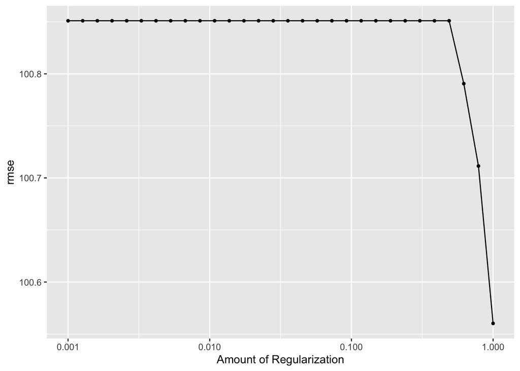

```r
#diagnostics
autoplot(lasso_res)
```

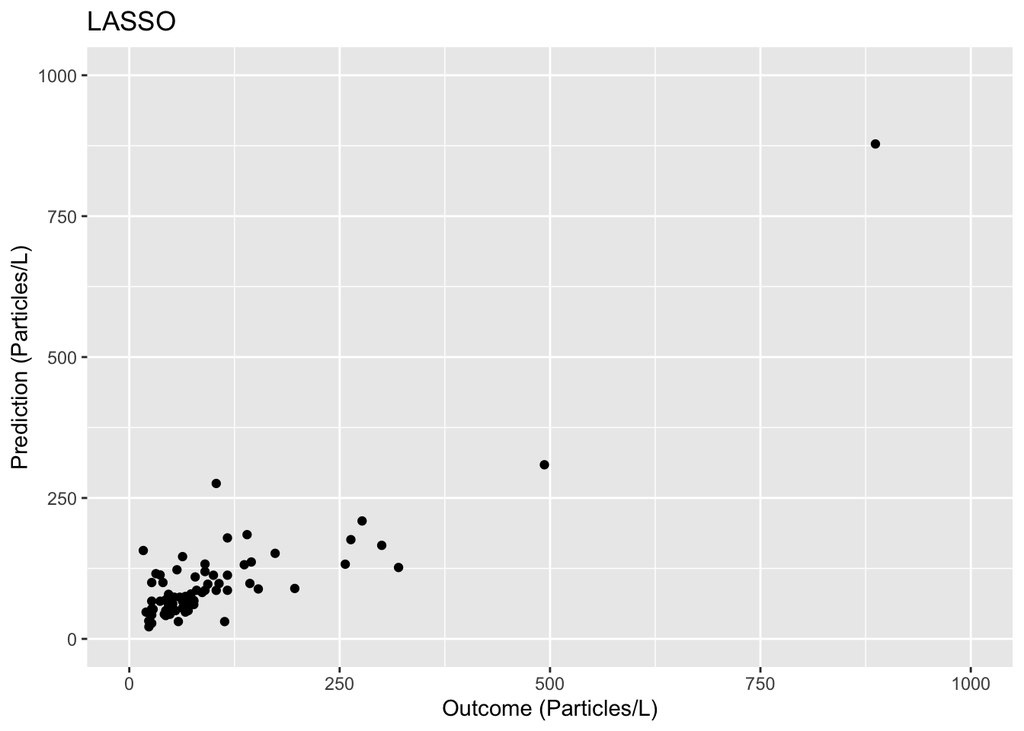

```r
#calculate residuals
lasso_resid <- lasso_fit %>%
  augment(train_data) %>% #this will add predictions to our df
  select(.pred, particles_l) %>%
  mutate(.resid = particles_l - .pred) #manually calculate residuals

#model predictions from tuned model vs actual outcomes
lasso_pred_plot <- ggplot(lasso_resid, aes(x = particles_l, y = .pred)) + geom_point() +
  labs(title = "LASSO", x = "Outcome (Particles/L)", y = "Prediction (Particles/L)")+ ylim(0, 1000) + xlim(0,1000)
lasso_pred_plot
```

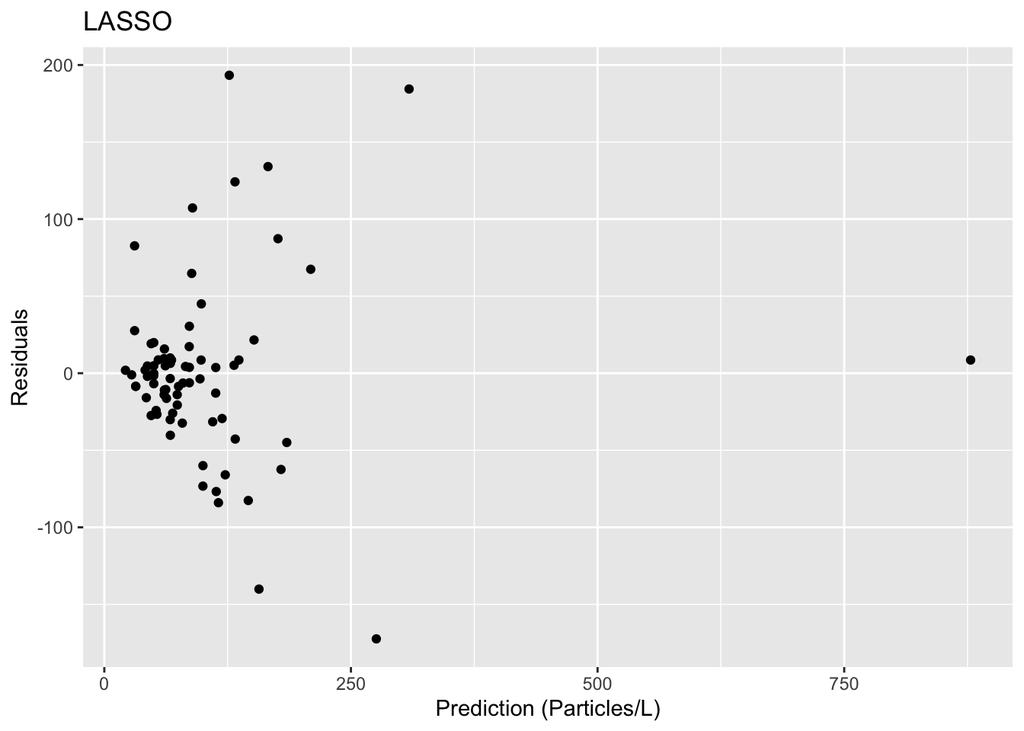

```r
ggsave(lasso_pred_plot, filename = here("results", "lasso_pred.png"))
#plot residuals vs predictions
lasso_resid_plot <- ggplot(lasso_resid, aes(y = .resid, x = .pred)) + geom_point() +
  labs(title = "LASSO", x = "Prediction (Particles/L)", y = "Residuals")
lasso_resid_plot #view plot
```

```r
#compare to null model
metrics_null_train #view null RMSE for train data
```

```
## # A tibble: 2 × 6
##   .metric .estimator  mean     n std_err .config
##   <chr>   <chr>      <dbl> <int>   <dbl> <chr>
## 1 rmse    standard    109.    25    11.6 Preprocessor1_Model1
## 2 rsq     standard    NaN      0    NA   Preprocessor1_Model1
```

```r
lasso_res %>% show_best(n=1) #view RMSE for best lasso model
```

```
## # A tibble: 1 × 7
##   penalty .metric .estimator  mean     n std_err .config
##     <dbl> <chr>   <chr>      <dbl> <int>   <dbl> <chr>
## 1       1 rmse    standard    101.    10    12.5 Preprocessor1_Model30
```

next I want to see what predictors are used in the best lasso model. also need to compare to null model

RMSE for best LASSO model is 100.5, compared to 109.4 RMSE for the null model. Still need to check included predictors for the best LASSO model.

# plot for how the number of predictors included in the LASSO model changes with the tuning parameter

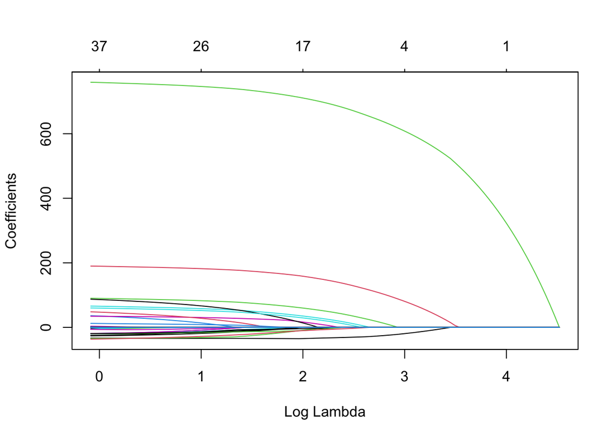

```r
x <- lasso_fit$fit$fit$fit
plot(x, "lambda")
```

```r
summary(best_lasso)
```

```
##     penalty    .config
##  Min.   :1   Length:1
##  1st Qu.:1   Class :character
##  Median :1   Mode  :character
##  Mean   :1
##  3rd Qu.:1
##  Max.   :1
```

```r
coefficients <- lasso_fit %>% extract_fit_parsnip() %>% tidy()
lasso_fit %>% extract_fit_parsnip() %>% tidy()
```

```
## # A tibble: 77 × 3
##    term          estimate penalty
##    <chr>            <dbl>   <dbl>
##  1 (Intercept)    67154.        1
##  2 lat                0         1
##  3 long               0         1
##  4 year             -33.2       1
##  5 month              0         1
##  6 visual_score       0         1
##  7 turbidity.ntu      0         1
##  8 temperature.c      0         1
##  9 e.coli.cfu         0         1
## 10 quarter            0         1
## # … with 67 more rows
```

Try modeling with data subset, including these variables: “particles_l”, “visual_score”, “turbidity.ntu”, “temperature.c”, “e.coli.cfu”, “population”, “dist”. We’ll do this in a separate Rmd document called `subset_modeling.Rmd`

# Decision tree

Next, we’ll try out a decision tree model

## Decision tree

```r
#going based off of tidymodels tutorial: tune parameters
#since we already split our data into test and train sets, we'll continue to use those here. they are `train_data` and `test_data`

#model specification
tune_spec <-
  decision_tree(
    cost_complexity = tune(),
    tree_depth = tune()
  ) %>%
  set_engine("rpart") %>%
  set_mode("regression")
tune_spec
```

```
## Decision Tree Model Specification (regression)
##
## Main Arguments:
##   cost_complexity = tune()
##   tree_depth = tune()
##
## Computational engine: rpart
```

```r
#tuning grid specification
tree_grid <- grid_regular(cost_complexity(),
                          tree_depth(),
                          levels = 5)
tree_grid
```

```
## # A tibble: 25 × 2
##    cost_complexity tree_depth
##              <dbl>      <int>
##  1    0.0000000001          1
##  2    0.0000000178          1
##  3    0.00000316            1
##  4    0.000562              1
##  5    0.1                   1
##  6    0.0000000001          4
##  7    0.0000000178          4
##  8    0.00000316            4
##  9    0.000562              4
## 10    0.1                   4
## # … with 15 more rows
```

```r
#cross validation
set.seed(123)
cell_folds <- vfold_cv(train_data)

#workflow
set.seed(123)

tree_wf <- workflow() %>%
  add_model(tune_spec) %>%
  add_recipe(MP_rec)

#model tuning with `tune_grid()`
tree_res <-
  tree_wf %>%
  tune_grid(
    resamples = cell_folds,
    grid = tree_grid
    )
```

[output not shown]

[output not shown]

[output not shown]

[output not shown]

[output not shown]

[output not shown]

[output not shown]

[output not shown]

[output not shown]

[output not shown]

[output not shown]

[output not shown]

[output not shown]

[output not shown]

[output not shown]

[output not shown]

[output not shown]

[output not shown]

[output not shown]

[output not shown]

[output not shown]

[output not shown]

[output not shown]

[output not shown]

[output not shown]

[output not shown]

[output not shown]

[output not shown]

[output not shown]

[output not shown]

[output not shown]

[output not shown]

[output not shown]

[output not shown]

[output not shown]

[output not shown]

[output not shown]

[output not shown]

[output not shown]

[output not shown]

[output not shown]

[output not shown]

[output not shown]

[output not shown]

[output not shown]

[output not shown]

[output not shown]

[output not shown]

[output not shown]

[output not shown]

[output not shown]

[output not shown]

[output not shown]

[output not shown]

[output not shown]

[output not shown]

[output not shown]

[output not shown]

[output not shown]

[output not shown]

[output not shown]

[output not shown]

[output not shown]

[output not shown]

[output not shown]

[output not shown]

[output not shown]

[output not shown]

[output not shown]

[output not shown]

[output not shown]

[output not shown]

[output not shown]

[output not shown]

[output not shown]

[output not shown]

[output not shown]

[output not shown]

[output not shown]

[output not shown]

[output not shown]

[output not shown]

[output not shown]

[output not shown]

[output not shown]

[output not shown]

[output not shown]

[output not shown]

[output not shown]

[output not shown]

[output not shown]

[output not shown]

[output not shown]

[output not shown]

[output not shown]

[output not shown]

[output not shown]

[output not shown]

[output not shown]

[output not shown]

[output not shown]

[output not shown]

[output not shown]

[output not shown]

[output not shown]

[output not shown]

[output not shown]

[output not shown]

[output not shown]

[output not shown]

[output not shown]

[output not shown]

[output not shown]

[output not shown]

[output not shown]

[output not shown]

[output not shown]

[output not shown]

[output not shown]

[output not shown]

[output not shown]

[output not shown]

[output not shown]

[output not shown]

[output not shown]

[output not shown]

[output not shown]

[output not shown]

[output not shown]

[output not shown]

[output not shown]

[output not shown]

[output not shown]

[output not shown]

[output not shown]

[output not shown]

[output not shown]

[output not shown]

[output not shown]

[output not shown]

[output not shown]

[output not shown]

[output not shown]

[output not shown]

[output not shown]

[output not shown]

[output not shown]

[output not shown]

[output not shown]

[output not shown]

[output not shown]

[output not shown]

[output not shown]

[output not shown]

[output not shown]

[output not shown]

[output not shown]

[output not shown]

[output not shown]

[output not shown]

[output not shown]

[output not shown]

[output not shown]

[output not shown]

[output not shown]

[output not shown]

[output not shown]

[output not shown]

[output not shown]

[output not shown]

[output not shown]

[output not shown]

[output not shown]

[output not shown]

[output not shown]

[output not shown]

[output not shown]

[output not shown]

[output not shown]

[output not shown]

[output not shown]

[output not shown]

[output not shown]

[output not shown]

[output not shown]

[output not shown]

[output not shown]

[output not shown]

[output not shown]

[output not shown]

[output not shown]

[output not shown]

[output not shown]

[output not shown]

[output not shown]

[output not shown]

[output not shown]

[output not shown]

[output not shown]

[output not shown]

[output not shown]

[output not shown]

```r
tree_res %>% collect_metrics()
```

```
## # A tibble: 50 × 8
##    cost_complexity tree_depth .metric .estimator    mean     n std_err .config
##              <dbl>      <int> <chr>   <chr>        <dbl> <int>   <dbl> <chr>
##  1    0.0000000001          1 rmse    standard   108.       10 21.4    Preproce…
##  2    0.0000000001          1 rsq     standard     0.184     8  0.0561 Preproce…
##  3    0.0000000178          1 rmse    standard   108.       10 21.4    Preproce…
##  4    0.0000000178          1 rsq     standard     0.184     8  0.0561 Preproce…
##  5    0.00000316            1 rmse    standard   108.       10 21.4    Preproce…
##  6    0.00000316            1 rsq     standard     0.184     8  0.0561 Preproce…
##  7    0.000562              1 rmse    standard   108.       10 21.4    Preproce…
##  8    0.000562              1 rsq     standard     0.184     8  0.0561 Preproce…
##  9    0.1                   1 rmse    standard   108.       10 21.4    Preproce…
## 10    0.1                   1 rsq     standard     0.184     8  0.0561 Preproce…
## # … with 40 more rows
```

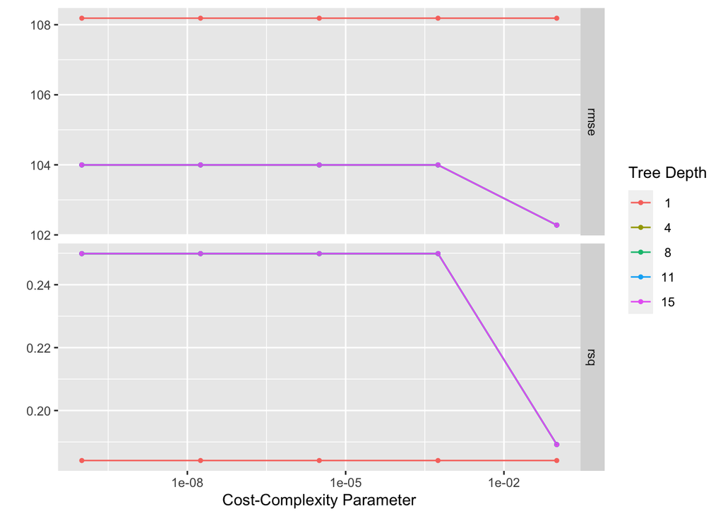

```r
#Here we see 25 candidate models, and the RMSE and Rsq for each
tree_res %>% autoplot() #view plot
```

```r
#select the best decision tree model
best_tree <- tree_res %>% select_best("rmse")
best_tree #view model details
```

```
## # A tibble: 1 × 3
##   cost_complexity tree_depth .config
##             <dbl>      <int> <chr>
## 1             0.1          4 Preprocessor1_Model10
```

```r
#finalize model workflow with best model
tree_final_wf <- tree_wf %>%
  finalize_workflow(best_tree)

#fit model
tree_fit <-
  tree_final_wf %>% fit(train_data)
tree_fit
```

```
## ══ Workflow [trained] ══════════════════════════════════════════════════════════
## Preprocessor: Recipe
## Model: decision_tree()
##
## ── Preprocessor ────────────────────────────────────────────────────────────────
## 1 Recipe Step
##
## • step_dummy()
##
## ── Model ───────────────────────────────────────────────────────────────────────
## n= 74
##
## node), split, n, deviance, yval
##       * denotes terminal node
##
## 1) root 74 1106210.0 101.80180
##   2) month< 9 59  216361.5  78.70056 *
##   3) month>=9 15  734515.6 192.66670 *
```

### Decision tree plots

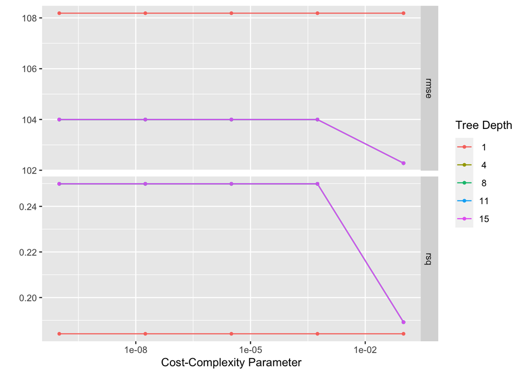

```r
#diagnostics
autoplot(tree_res)
```

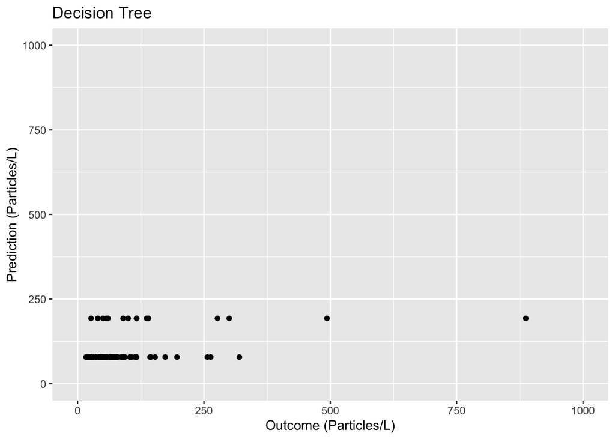

```r
#calculate residuals - originally got stuck trying out lots of different methods for this. took inspiration from Zane's code to manually calculate residuals rather than using some of the built in functions that I could not get to cooperate
tree_resid <- tree_fit %>%
  augment(train_data) %>% #this will add predictions to our df
  select(.pred, particles_l) %>%
  mutate(.resid = particles_l - .pred) #manually calculate residuals

#model predictions from tuned model vs actual outcomes
tree_pred_plot <- ggplot(tree_resid, aes(x = particles_l, y = .pred)) + geom_point() +
  labs(title = "Decision Tree", x = "Outcome (Particles/L)", y = "Prediction (Particles/L)")+ ylim(0, 1000) + xlim(0,1000)
tree_pred_plot
```

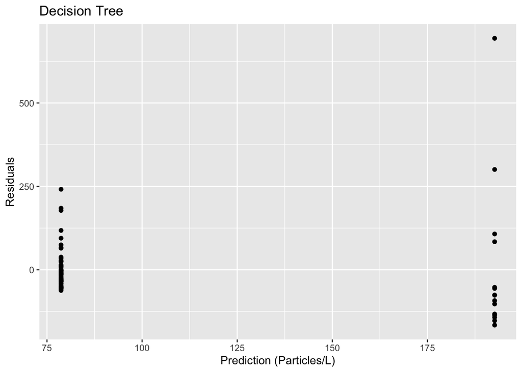

```r
#plot residuals vs predictions
tree_resid_plot <- ggplot(tree_resid, aes(y = .resid, x = .pred)) + geom_point() +
  labs(title = "Decision Tree", x = "Prediction (Particles/L)", y = "Residuals")
tree_resid_plot #view plot
```

```r
#compare to null model
metrics_null_train #view null RMSE for train data
```

```
## # A tibble: 2 × 6
##   .metric .estimator  mean     n std_err .config
##   <chr>   <chr>      <dbl> <int>   <dbl> <chr>
## 1 rmse    standard    109.    25    11.6 Preprocessor1_Model1
## 2 rsq     standard    NaN      0    NA   Preprocessor1_Model1
```

```r
tree_res %>% show_best(n=1) #view RMSE for best decision tree model
```

```
## # A tibble: 1 × 8
##   cost_complexity tree_depth .metric .estimator  mean     n std_err .config
##             <dbl>      <int> <chr>   <chr>      <dbl> <int>   <dbl> <chr>
## 1             0.1          4 rmse    standard    102.    10    21.2 Preprocesso…
```

The best decision tree has an RMSE of 102.2, which is better than the null model RMSE of 109. However, the decision tree did not perform as well well as the Lasso regularized model, which had an RMSE of about 100. Based on the outcome/prediction plot, it appears that the model is making one of two predictions for any given actual outcome. This indicates that this is not a good model, as we don’t see the expected 45 degree diagonal line where predictions correlate closely with outcomes.

# Random forest

Finally, let’s try out a random forest.

### split data into train and test subsets with only COMPLETE CASES

```r
data %>% is.na() %>% summary() #check out missing cases
```

```
##     site         watershed          lat             long
##  Mode :logical   Mode :logical   Mode :logical   Mode :logical
##  FALSE:109       FALSE:109       FALSE:109       FALSE:109
##
##  particles_l        date            year           month
##  Mode :logical   Mode :logical   Mode :logical   Mode :logical
##  FALSE:109       FALSE:109       FALSE:109       FALSE:109
##
##  visual_score    turbidity.ntu   temperature.c   e.coli.cfu
##  Mode :logical   Mode :logical   Mode :logical   Mode :logical
##  FALSE:99        FALSE:104       FALSE:101       FALSE:103
##  TRUE :10        TRUE :5         TRUE :8         TRUE :6
##   quarter           FIPS         population         wrf
##  Mode :logical   Mode :logical   Mode :logical   Mode :logical
##  FALSE:106       FALSE:109       FALSE:109       FALSE:109
##  TRUE :3
##     dist
##  Mode :logical
##  FALSE:109
##
```

```r
complete <- data %>% na.omit() #save complete cases
complete <- complete %>% select(-"visual_score")

# set seed for reproducible analysis (instead of random subset each time)
set.seed(123)
#subset 3/4 of data as training set
complete_data_split <- initial_split(complete,
                            prop = 7/10,
                            strata = particles_l) #stratify by MP concentration for balanced outcome

#save sets as data frames
complete_train_data <- training(complete_data_split)
complete_test_data <- testing(complete_data_split)

#reset recipe with adjusted, complete data
MP_rec <- recipe(particles_l ~ ., data = complete_train_data) %>% step_dummy(all_nominal())
#reset cell_folds
set.seed(123)
cell_folds <- vfold_cv(complete_train_data)
```

## Random forest

```r
#based on tidymodels tutorial: case study
library(parallel)
cores <- parallel::detectCores()
cores
```

```
## [1] 8
```

```r
#model specification
r_forest <- rand_forest(mtry = tune(), min_n = tune(), trees = tune()) %>% set_engine("ranger", num.threads = cores) %>% set_mode("regression")

#set workflow
r_forest_wf <- workflow() %>% add_model(r_forest) %>% add_recipe(MP_rec)

#tuning grid specification
rf_grid  <- expand.grid(mtry = c(3, 4, 5, 6), min_n = c(40,50,60), trees = c(500,1000)  )
#what we will tune:
r_forest %>% parameters()
```

```
## Collection of 3 parameters for tuning
##
##  identifier  type    object
##        mtry  mtry nparam[?]
##       trees trees nparam[+]
##       min_n min_n nparam[+]
##
## Model parameters needing finalization:
##    # Randomly Selected Predictors ('mtry')
##
## See `?dials::finalize` or `?dials::update.parameters` for more information.
```

```r
#tuning with CV and tune_grid

r_forest_res <-
  r_forest_wf %>%
  tune_grid(resamples = cell_folds,
            grid = rf_grid,
            control = control_grid(save_pred = TRUE),
            metrics = metric_set(rmse))
```

[output not shown]

[output not shown]

[output not shown]

[output not shown]

[output not shown]

[output not shown]

[output not shown]

[output not shown]

[output not shown]

[output not shown]

[output not shown]

[output not shown]

[output not shown]

[output not shown]

[output not shown]

[output not shown]

[output not shown]

[output not shown]

[output not shown]

[output not shown]

[output not shown]

[output not shown]

[output not shown]

[output not shown]

[output not shown]

[output not shown]

[output not shown]

[output not shown]

[output not shown]

[output not shown]

[output not shown]

[output not shown]

[output not shown]

[output not shown]

[output not shown]

[output not shown]

[output not shown]

[output not shown]

[output not shown]

[output not shown]

[output not shown]

[output not shown]

[output not shown]

[output not shown]

[output not shown]

[output not shown]

[output not shown]

[output not shown]

[output not shown]

[output not shown]

[output not shown]

[output not shown]

[output not shown]

[output not shown]

[output not shown]

[output not shown]

[output not shown]

[output not shown]

[output not shown]

[output not shown]

[output not shown]

[output not shown]

[output not shown]

[output not shown]

[output not shown]

[output not shown]

[output not shown]

[output not shown]

[output not shown]

[output not shown]

[output not shown]

[output not shown]

[output not shown]

[output not shown]

[output not shown]

[output not shown]

[output not shown]

[output not shown]

[output not shown]

[output not shown]

[output not shown]

[output not shown]

[output not shown]

[output not shown]

[output not shown]

[output not shown]

[output not shown]

[output not shown]

[output not shown]

[output not shown]

[output not shown]

[output not shown]

[output not shown]

[output not shown]

[output not shown]

[output not shown]

[output not shown]

[output not shown]

[output not shown]

[output not shown]

[output not shown]

[output not shown]

[output not shown]

[output not shown]

[output not shown]

[output not shown]

[output not shown]

[output not shown]

[output not shown]

[output not shown]

[output not shown]

[output not shown]

[output not shown]

[output not shown]

[output not shown]

[output not shown]

[output not shown]

[output not shown]

[output not shown]

[output not shown]

[output not shown]

[output not shown]

[output not shown]

[output not shown]

[output not shown]

[output not shown]

[output not shown]

[output not shown]

[output not shown]

[output not shown]

[output not shown]

[output not shown]

[output not shown]

[output not shown]

[output not shown]

[output not shown]

[output not shown]

[output not shown]

[output not shown]

[output not shown]

[output not shown]

[output not shown]

[output not shown]

[output not shown]

[output not shown]

[output not shown]

[output not shown]

[output not shown]

[output not shown]

[output not shown]

[output not shown]

[output not shown]

[output not shown]

[output not shown]

[output not shown]

[output not shown]

[output not shown]

[output not shown]

[output not shown]

[output not shown]

[output not shown]

[output not shown]

[output not shown]

[output not shown]

[output not shown]

[output not shown]

[output not shown]

[output not shown]

[output not shown]

[output not shown]

[output not shown]

[output not shown]

[output not shown]

[output not shown]

[output not shown]

[output not shown]

[output not shown]

[output not shown]

[output not shown]

[output not shown]

[output not shown]

[output not shown]

[output not shown]

[output not shown]

[output not shown]

[output not shown]

[output not shown]

[output not shown]

[output not shown]

[output not shown]

[output not shown]

[output not shown]

[output not shown]

[output not shown]

[output not shown]

[output not shown]

[output not shown]

[output not shown]

[output not shown]

[output not shown]

[output not shown]

[output not shown]

[output not shown]

[output not shown]

[output not shown]

[output not shown]

[output not shown]

[output not shown]

[output not shown]

[output not shown]

[output not shown]

[output not shown]

[output not shown]

[output not shown]

[output not shown]

[output not shown]

[output not shown]

[output not shown]

[output not shown]

[output not shown]

[output not shown]

[output not shown]

[output not shown]

[output not shown]

[output not shown]

[output not shown]

[output not shown]

[output not shown]

[output not shown]

[output not shown]

[output not shown]

[output not shown]

[output not shown]

[output not shown]

[output not shown]

[output not shown]

[output not shown]

[output not shown]

[output not shown]

[output not shown]

[output not shown]

[output not shown]

[output not shown]

[output not shown]

[output not shown]

[output not shown]

[output not shown]

[output not shown]

[output not shown]

[output not shown]

[output not shown]

[output not shown]

[output not shown]

[output not shown]

[output not shown]

[output not shown]

[output not shown]

[output not shown]

[output not shown]

[output not shown]

[output not shown]

[output not shown]

[output not shown]

[output not shown]

[output not shown]

[output not shown]

[output not shown]

[output not shown]

[output not shown]

[output not shown]

[output not shown]

[output not shown]

[output not shown]

[output not shown]

[output not shown]

[output not shown]

[output not shown]

[output not shown]

[output not shown]

[output not shown]

[output not shown]

[output not shown]

[output not shown]

[output not shown]

[output not shown]

[output not shown]

[output not shown]

[output not shown]

[output not shown]

[output not shown]

[output not shown]

[output not shown]

[output not shown]

[output not shown]

[output not shown]

[output not shown]

[output not shown]

[output not shown]

[output not shown]

[output not shown]

[output not shown]

[output not shown]

[output not shown]

[output not shown]

[output not shown]

[output not shown]

[output not shown]

[output not shown]

[output not shown]

[output not shown]

[output not shown]

[output not shown]

[output not shown]

[output not shown]

[output not shown]

[output not shown]

[output not shown]

[output not shown]

[output not shown]

[output not shown]

```r
#view top models
r_forest_res %>% show_best(metric = "rmse")
```

```
## # A tibble: 5 × 9
##    mtry trees min_n .metric .estimator  mean     n std_err .config
##   <dbl> <dbl> <dbl> <chr>   <chr>      <dbl> <int>   <dbl> <chr>
## 1     3   500    60 rmse    standard    109.     5    54.8 Preprocessor1_Model09
## 2     3  1000    60 rmse    standard    109.     5    54.8 Preprocessor1_Model21
## 3     4   500    60 rmse    standard    109.     5    54.8 Preprocessor1_Model10
## 4     5   500    60 rmse    standard    109.     5    54.8 Preprocessor1_Model11
## 5     6   500    60 rmse    standard    109.     5    54.7 Preprocessor1_Model12
```

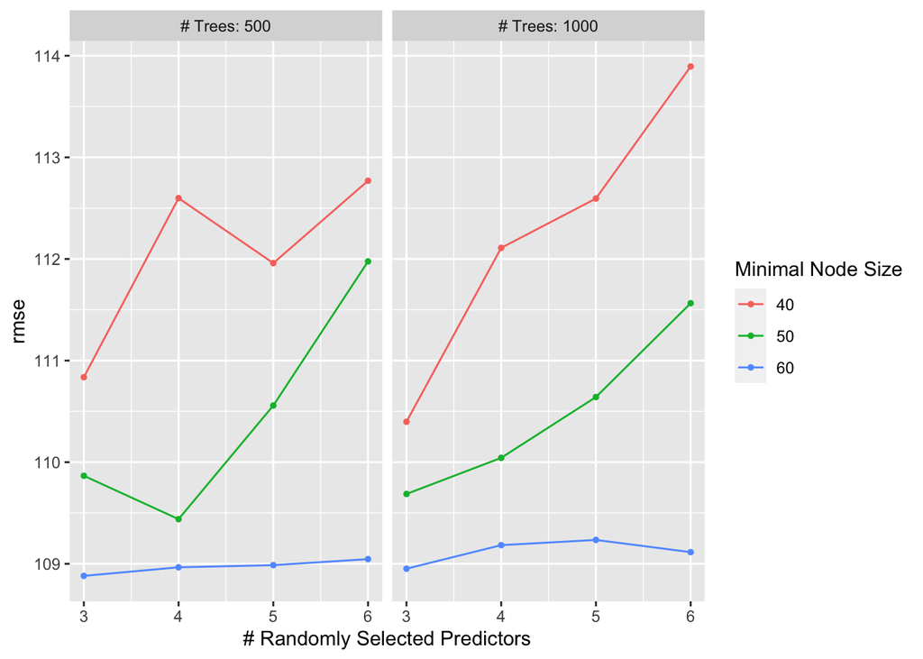

```r
#view plot of models performance
autoplot(r_forest_res)
```

```r
#select best model
rf_best <- r_forest_res %>% select_best(metric = "rmse")
rf_best
```

```
## # A tibble: 1 × 4
##    mtry trees min_n .config
##   <dbl> <dbl> <dbl> <chr>
## 1     3   500    60 Preprocessor1_Model09
```

```r
#finalize workflow with top model
rf_final_wf <- r_forest_wf %>% finalize_workflow(rf_best)

#fit model with finalized WF
rf_fit <- rf_final_wf %>% fit(complete_train_data)
```

Here, we get an error message that all models failed, note: missing value in visual_score. Let’s go back and use only complete cases for the random forest.

The issue was in “cell_folds” which had originated earlier in the Rmd and didn’t include the updated complete case dataset. Added a line of code to reset cell_folds at this stage of the Rmd in order to use complete cases only. We still get some error messages but are able to run the model.

### Random forest plots

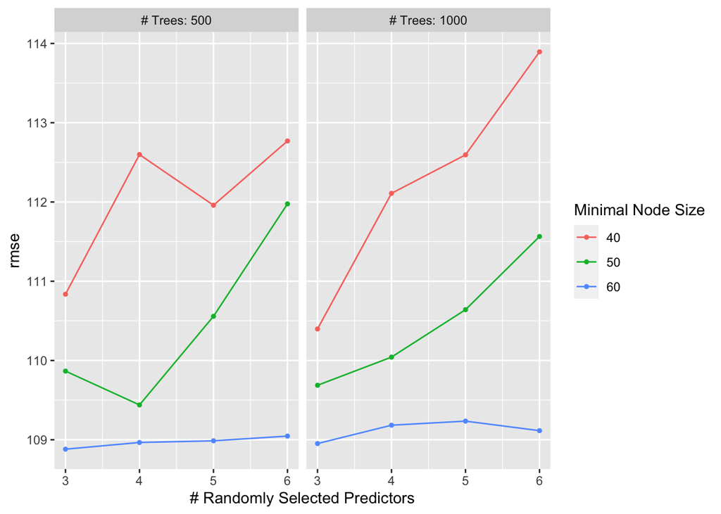

```r
#diagnostics
autoplot(r_forest_res)
```

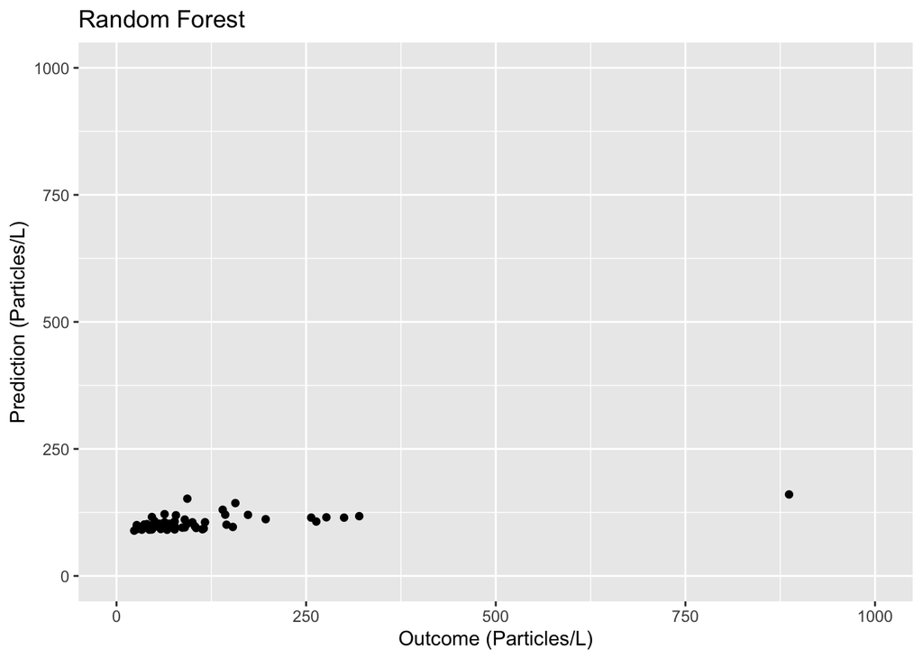

```r
#calculate residuals
rf_resid <- rf_fit %>%
  augment(complete_train_data) %>% #this will add predictions to our df
  select(.pred, particles_l) %>%
  mutate(.resid = particles_l - .pred) #manually calculate residuals

#model predictions from tuned model vs actual outcomes
rf_pred_plot <- ggplot(rf_resid, aes(x = particles_l, y = .pred)) + geom_point() +
  labs(title = "Random Forest", x = "Outcome (Particles/L)", y = "Prediction (Particles/L)")+ ylim(0, 1000) + xlim(0,1000)
rf_pred_plot
```

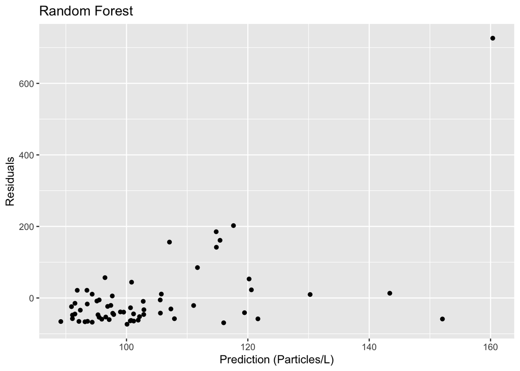

```r
#plot residuals vs predictions
rf_resid_plot <- ggplot(rf_resid, aes(y = .resid, x = .pred)) + geom_point() +
  labs(title = "Random Forest", x = "Prediction (Particles/L)", y = "Residuals")
rf_resid_plot #view plot
```

```r
#compare to null model
metrics_null_train #view null RMSE for train data
```

```
## # A tibble: 2 × 6
##   .metric .estimator  mean     n std_err .config
##   <chr>   <chr>      <dbl> <int>   <dbl> <chr>
## 1 rmse    standard    109.    25    11.6 Preprocessor1_Model1
## 2 rsq     standard    NaN      0    NA   Preprocessor1_Model1
```

```r
r_forest_res %>% show_best(n=1) #view RMSE for best decision tree model
```

```
## # A tibble: 1 × 9
##    mtry trees min_n .metric .estimator  mean     n std_err .config
##   <dbl> <dbl> <dbl> <chr>   <chr>      <dbl> <int>   <dbl> <chr>
## 1     3   500    60 rmse    standard    109.     5    54.8 Preprocessor1_Model09
```

# Model comparison plots

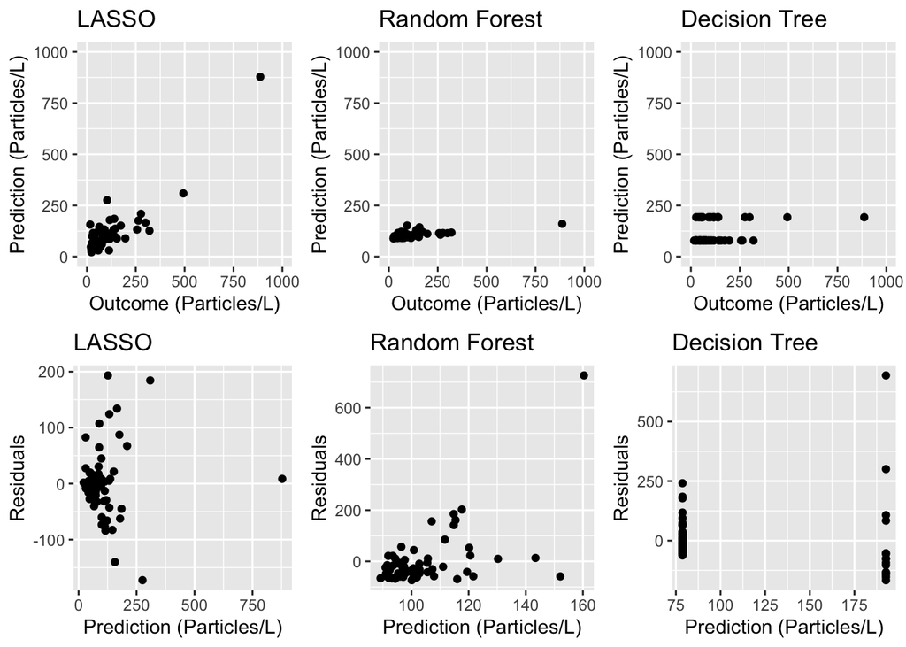

```r
model_grid <- grid.arrange(lasso_pred_plot, rf_pred_plot, tree_pred_plot, lasso_resid_plot, rf_resid_plot, tree_resid_plot, ncol = 3)
```

```r
ggsave(model_grid, filename = here("results", "model_grid.png"))
```

# Model selection : LASSO

```r
#Based on model performance plots and RMSE, we've selected the LASSO model. Let's evaluate it with the test data.

#fit to test data
last_lasso_fit <- lasso_final_wf %>% last_fit(data_split)
```

```
## ! train/test split: preprocessor 1/1, model 1/1 (predictions): There are new levels in a fac...
```

```r
last_lasso_fit %>% collect_metrics()
```

```
## # A tibble: 2 × 4
##   .metric .estimator .estimate .config
##   <chr>   <chr>          <dbl> <chr>
## 1 rmse    standard   302.      Preprocessor1_Model1
## 2 rsq     standard     0.00152 Preprocessor1_Model1
```

It appears that the lasso model receives an RMSE of ~300 when run with the test data. Compared to the RMSE of 100 with the train data, this is not great performance and indicates that the model overfits the train data.

# Variable importance

```r
library(parsnip)
var_importance <- last_lasso_fit %>%
  purrr::pluck(".workflow", 1) %>%
  workflows::extract_fit_parsnip() %>%
  vip(num_features = 20)

ggsave(var_importance, filename = here("results", "var_importance.png"))
```

# Final lasso plots

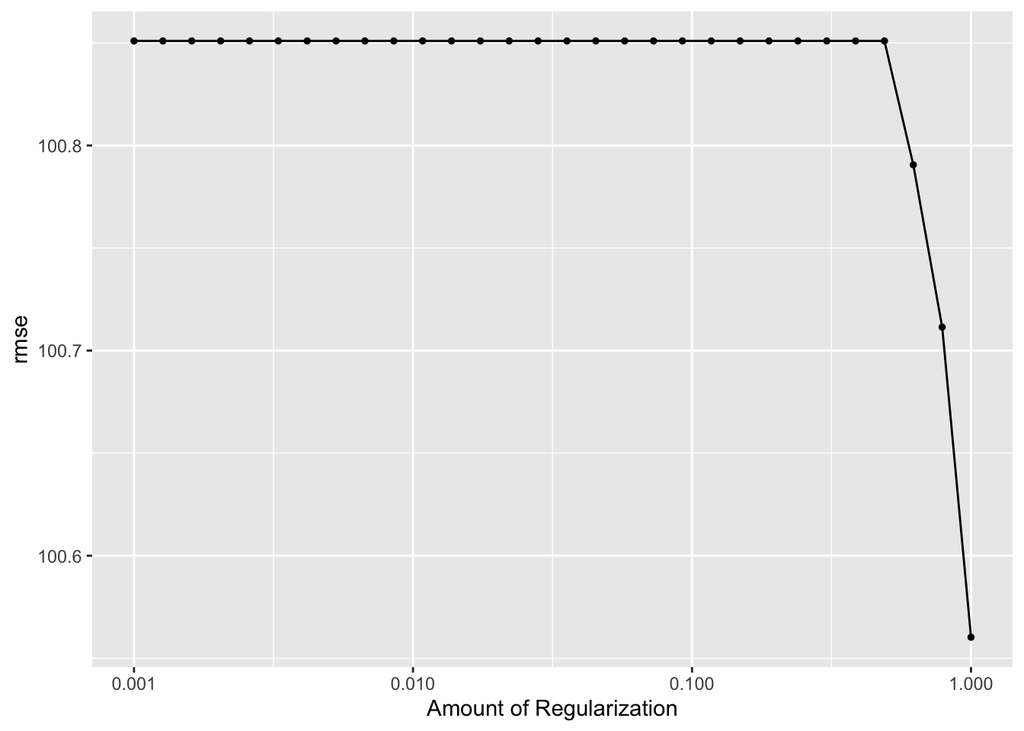

```r
#diagnostics
autoplot(lasso_res)
```

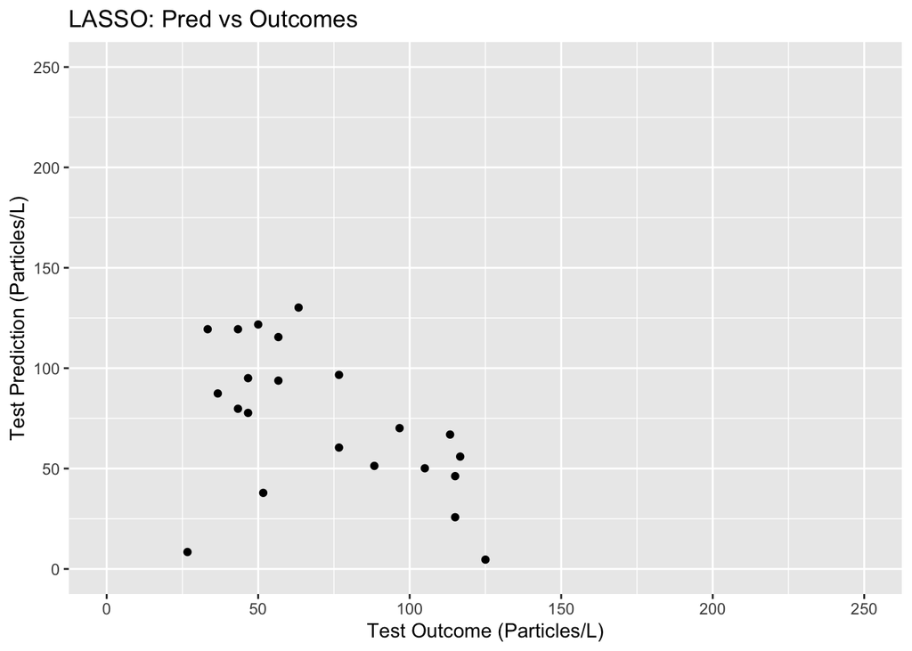

```r
#calculate residuals
last_lasso_resid <- last_lasso_fit %>%
  augment() %>% #this will add predictions to our df
  select(.pred, particles_l) %>%
  mutate(.resid = particles_l - .pred) #manually calculate residuals

#model predictions from tuned model vs actual outcomes
last_lasso_pred_plot <- ggplot(last_lasso_resid, aes(x = particles_l, y = .pred)) + geom_point() +
  labs(title = "LASSO: Pred vs Outcomes", x = "Test Outcome (Particles/L)", y = "Test Prediction (Particles/L)")+ ylim(0, 250) + xlim(0,250)
last_lasso_pred_plot
```

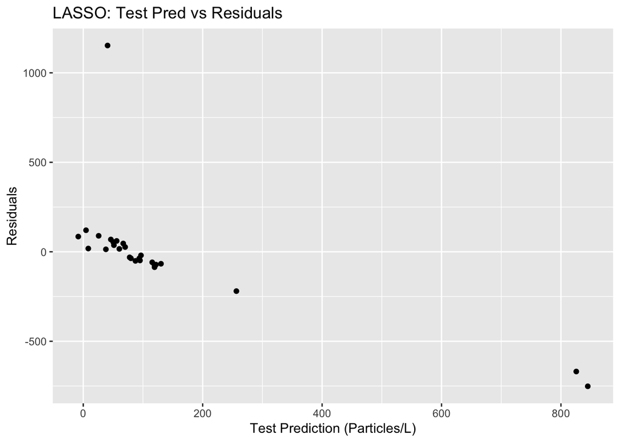

```r
ggsave(last_lasso_pred_plot, filename = here("results", "last_lasso_pred.png"))
#plot residuals vs predictions
last_lasso_resid_plot <- ggplot(last_lasso_resid, aes(y = .resid, x = .pred)) + geom_point() +
  labs(title = "LASSO: Test Pred vs Residuals", x = "Test Prediction (Particles/L)", y = "Residuals")
last_lasso_resid_plot #view plot
```

```r
#compare to null model
metrics_null_train #view null RMSE for train data
```

```
## # A tibble: 2 × 6
##   .metric .estimator  mean     n std_err .config
##   <chr>   <chr>      <dbl> <int>   <dbl> <chr>
## 1 rmse    standard    109.    25    11.6 Preprocessor1_Model1
## 2 rsq     standard    NaN      0    NA   Preprocessor1_Model1
```

```r
last_lasso_fit %>% collect_metrics() #view RMSE for best lasso model
```

```
## # A tibble: 2 × 4
##   .metric .estimator .estimate .config
##   <chr>   <chr>          <dbl> <chr>
## 1 rmse    standard   302.      Preprocessor1_Model1
## 2 rsq     standard     0.00152 Preprocessor1_Model1
```